# App Sentiment Review

## App sentiment review is the process of analyzing user feedback and reviews on platforms like app stores and social media to understand whether people have positive, negative, or neutral opinions about a mobile application. This helps developers and businesses improve their app based on user perceptions. Positive sentiments indicate user satisfaction, while negative sentiments highlight areas for improvement.

### Let's begin the app reviews sentiment analysis task by importing the required Python libraries and the [dataset](https://statso.io/sentiment-analysis-case-study/):

```python
import pandas as pd
import matplotlib.pyplot as plt
import seaborn as sns

# Load the dataset
linkedin_data = pd.read_csv("E:\\Portfolio_projects\\Python\\linkedin-reviews.csv")

# Display the first few rows of the dataset
print(linkedin_data.head())
```

```
                                              Review  Rating
0  Does absolutely nothing for a LinkedIn beginne...       1
1                            Force close(galaxy tab)       1
2  Slow and it tries to upload your contacts with...       1
3  Add ability to customize the profile and move ...       4
4  Good app, but it's a pain that it's not possib...       4
```

### The dataset is comprised of two columns: one named "Review," containing textual feedback, and another named "Rating," which holds numerical ratings corresponding to the reviews.

```python
# Column Information
print(linkedin_data.info())
```

```
<class 'pandas.core.frame.DataFrame'>
RangeIndex: 702 entries, 0 to 701
Data columns (total 2 columns):
 #   Column  Non-Null Count  Dtype
---  ------  --------------  -----
 0   Review  702 non-null    object
 1   Rating  702 non-null    int64
dtypes: int64(1), object(1)
memory usage: 11.1+ KB
None
```

### Exploratory Data Analysis

### Let's systematically explore the data. First, we'll analyze the distribution of ratings to comprehend the overall sentiment expressed in the reviews. Subsequently, we can broaden our investigation to assess factors such as the length of the reviews, potentially extracting insights from the textual content of the feedback.

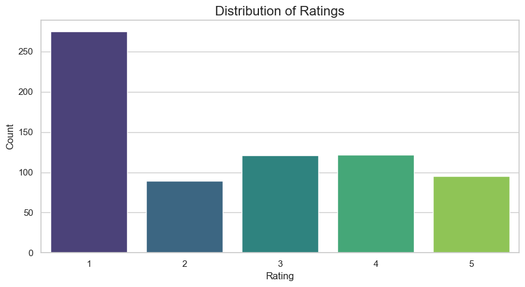

```python
# Plotting the distribution of ratings
# Set the Seaborn style
sns.set(style="whitegrid")

# Create a figure and axes
fig, ax = plt.subplots(figsize=(9, 5))

# Use Seaborn's countplot for better visualization
sns.countplot(data=linkedin_data, x='Rating', ax=ax, palette='viridis')

# Set plot title and labels
ax.set_title('Distribution of Ratings', fontsize=16)
ax.set_xlabel('Rating', fontsize=12)
ax.set_ylabel('Count', fontsize=12)

# Improve readability of x-axis labels
ax.tick_params(axis='x', rotation=0)

# Display the plot
plt.tight_layout()
plt.show()
```

### Here's an overview of the rating distribution in the LinkedIn reviews dataset, providing a visual representation of the number of reviews corresponding to each rating category, ranging from 1 to 5.

### Moving forward, we will examine the length of the reviews, as it can occasionally be associated with the sentiment or level of detail in the feedback. Our approach involves initially computing the length of each review and subsequently presenting the data visually.

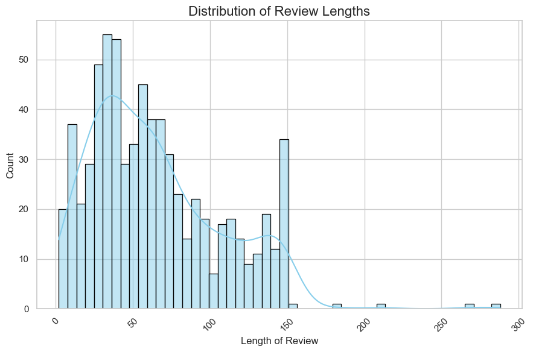

```python
# Calculating the length of each review
linkedin_data['Review Length'] = linkedin_data['Review'].apply(len)
# Set the Seaborn style
sns.set(style="whitegrid")

# Create a figure and axes
fig, ax = plt.subplots(figsize=(9, 6))

# Use Seaborn's histplot for better visualization with KDE (Kernel Density Estimation)
sns.histplot(linkedin_data['Review Length'], bins=50, kde=True, color='skyblue', edgecolor='black')

# Set plot title and labels
ax.set_title('Distribution of Review Lengths', fontsize=16)
ax.set_xlabel('Length of Review', fontsize=12)
ax.set_ylabel('Count', fontsize=12)

# Improve readability of x-axis labels
ax.tick_params(axis='x', labelrotation=45)

# Display the plot
plt.tight_layout()
plt.show()
```

## Adding Sentiment Labels in the Data

### The subsequent task involves assigning sentiments to the data. TextBlob will be employed for this purpose, providing a polarity score that spans from -1 (indicating a very negative sentiment) to 1 (indicating a very positive sentiment) for each text. Utilizing these scores, we can categorize the sentiment of each review as positive, neutral, or negative.

```python
#pip install textblob
from textblob import TextBlob

def textblob_sentiment_analysis(review):
    # Analyzing the sentiment of the review
    polarity = TextBlob(review).sentiment.polarity
    # Classifying based on polarity
    if polarity > 0.1:
        return 'Positive'
    elif polarity < -0.1:
        return 'Negative'
    else:
        return 'Neutral'

# Applying TextBlob sentiment analysis to the reviews using a lambda function
linkedin_data['Sentiment'] = linkedin_data['Review'].apply(lambda x: textblob_sentiment_analysis(x))

# Displaying the first few rows with the sentiment
print(linkedin_data.head())
```

```
                                              Review  Rating  Review Length  \
0  Does absolutely nothing for a LinkedIn beginne...       1             80
1                            Force close(galaxy tab)       1             23
2  Slow and it tries to upload your contacts with...       1             61
3  Add ability to customize the profile and move ...       4             90
4  Good app, but it's a pain that it's not possib...       4            133

  Sentiment
0  Negative
1   Neutral
2  Negative
3   Neutral
4  Positive
```

### The dataset has now been updated with sentiment labels assigned to each review. These labels categorize the sentiment as Positive, Negative, or Neutral, determined by the polarity scores computed by TextBlob.

## Analyzing App Reviews Sentiments

### Now that our dataset has been labeled, let's proceed with analyzing the distribution of sentiments within the dataset. This initial analysis will provide us with a fundamental insight into the overall tendency of sentiments expressed in the reviews.

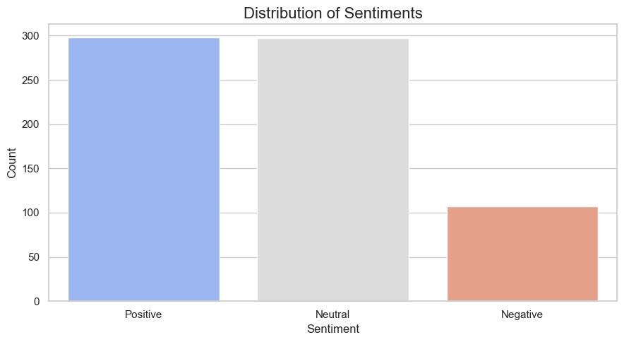

```python
# Analyzing the distribution of sentiments
sentiment_distribution = linkedin_data['Sentiment'].value_counts()

# Set the Seaborn style
sns.set(style="whitegrid")

# Create a figure and axes
fig, ax = plt.subplots(figsize=(9, 5))

# Use Seaborn's barplot for better visualization
sns.barplot(x=sentiment_distribution.index, y=sentiment_distribution.values, palette='coolwarm', ax=ax)

# Set plot title and labels
ax.set_title('Distribution of Sentiments', fontsize=16)
ax.set_xlabel('Sentiment', fontsize=12)
ax.set_ylabel('Count', fontsize=12)

# Improve readability of x-axis labels
ax.tick_params(axis='x', rotation=0)

# Display the plot
plt.tight_layout()
plt.show()
```

### Therefore, despite the app receiving low ratings, it is notable that reviewers do not employ numerous negative expressions in their app reviews.

### Next, we'll explore the relationship between sentiments and ratings. This analysis seeks to determine if there is a connection between the sentiment conveyed in the text and the numerical rating. To achieve this, we'll examine the distribution of sentiments across different rating levels.

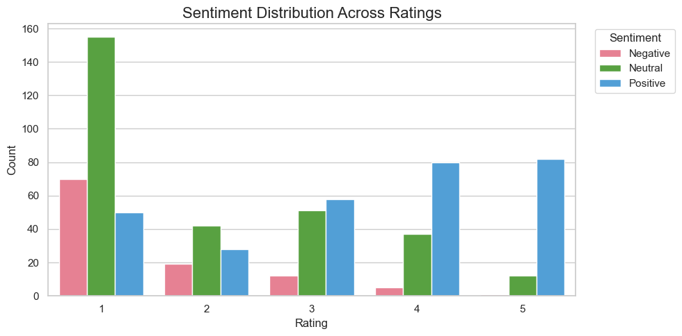

```python
# Create a figure and axes
fig, ax = plt.subplots(figsize=(10, 5))

# Use Seaborn's countplot with hue for better visualization
sns.countplot(data=linkedin_data, x='Rating', hue='Sentiment', palette='husl', ax=ax)

# Set plot title and labels
ax.set_title('Sentiment Distribution Across Ratings', fontsize=16)
ax.set_xlabel('Rating', fontsize=12)
ax.set_ylabel('Count', fontsize=12)

# Add legend with title
ax.legend(title='Sentiment', loc='upper right', bbox_to_anchor=(1.2, 1))

# Display the plot
plt.tight_layout()
plt.show()
```

### Now, we'll conduct a text analysis to identify prevalent words or themes associated with each sentiment category. This entails examining the most frequently used words in positive, negative, and neutral reviews through the creation of a word cloud.

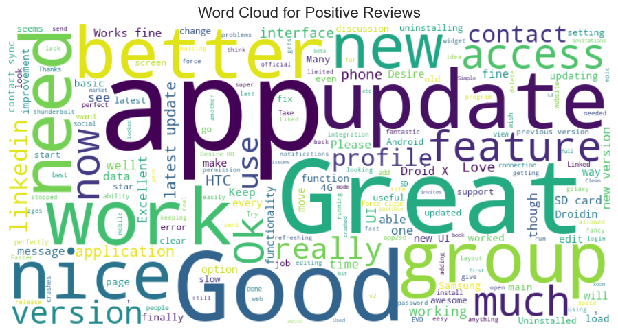

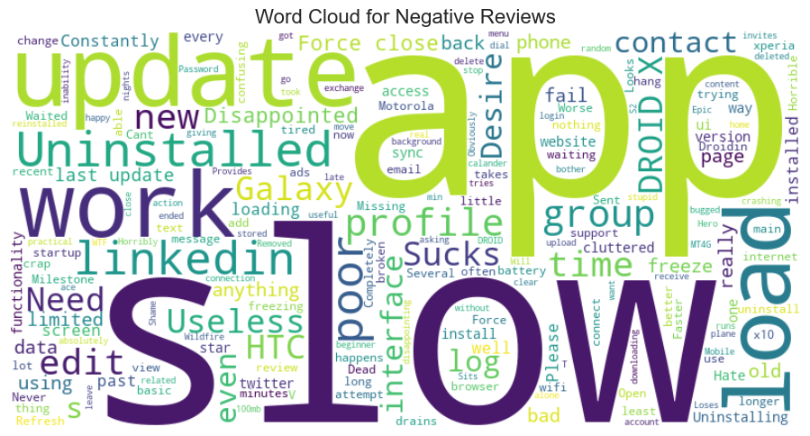

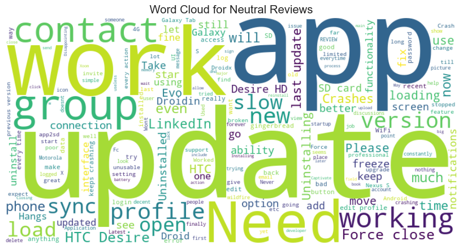

```python
#pip install wordcloud
from wordcloud import WordCloud
# Function to generate word cloud for each sentiment
def generate_word_cloud(sentiment):
    text = ' '.join(review for review in linkedin_data[linkedin_data['Sentiment'] == sentiment]['Review'])
    wordcloud = WordCloud(width=800, height=400, background_color='white', colormap='viridis').generate(text)

    # Create a figure and axes
    fig, ax = plt.subplots(figsize=(10, 5))

    # Display the word cloud
    ax.imshow(wordcloud, interpolation='bilinear')

    # Set plot title and hide axes
    ax.set_title(f'Word Cloud for {sentiment} Reviews', fontsize=16)
    ax.axis('off')

    # Display the plot
    plt.tight_layout()
    plt.show()

# Generating word clouds for each sentiment
for sentiment in ['Positive', 'Negative', 'Neutral']:
    generate_word_cloud(sentiment)
```